# Project 2

STATS 220 Semester One 2023

Francesca Domanska

2023-03-23

```r
knitr::opts_chunk$set(echo = TRUE, message = FALSE, error = FALSE, warning = FALSE)

library(tidyverse)
# Read csv. and renaming all variables
learning_data <- read.csv("https://docs.google.com/spreadsheets/d/e/2PACX-1vRUa6zoleX1m8zk3bWWM71ZCv3gZSVzDQ0Nuy-cxWmJjZ8ipMavqueUg53KljfCdtJfZUHcFqotICqP/pub?gid=2000943037&single=true&output=csv") %>%
  rename(eng_lang = 2,
         fluent_lang = 3,
         light_lang = 4,
         school_lang = 5,
         learn_lang = 16)
```

## Introduction

The aspects I wanted to focus on was how many languages students can speak fluently and if their first language is english. I also wanted to focus on whether students are currently learning languages and whether or not they learnt any at educational institutions. The purpose of this is because I believe the New Zealand curriculum is not encouraging young people to learn languages. From this data I wanted to gauge what learning habits and other factors, play in young people’s ability to learn and speak multiple languages.

One of the guidelines for the design of the form I followed was to include two questions generating a numeric answer using short answer questions. I had to consider how to make sure that people would not give unrealistic values such as negatives or non-whole numbers. Therefore for both languages questions I had to regex code such as: ^(1[0-2]|[1-9])$ for the fluent languages and ^(1[0-2]|[0-9])$ for the lightly spoken languages. I also made sure that for fluent languages, the minimum amount you can put in is one, assuming that everyone at the University of Auckland is proficient in at least one language.

Categorical data was generated using check boxes was so that there were fixed answers and the answer format would be consistent throughout. This makes it easier to analyse data as people have to select an option, instead of everyone answering similar things in different formats, making it difficult to analyse the data. However, the data collected from these questions us not strictly “tidy” because it does not meet the criteria of each cell being a single value. When analysing the data, it groups checked box variables together, causing some of the cells to be multiple values. Also the term “tidy” data has the connotation that it has been cleaned. This means that invalid observations are removed, however this data has not been manipulated in any way.

Click **[here](https://forms.gle/3VuqA64z8vJTpj3w8)** to access my Google Form.

## Analytics

Click **[here](https://docs.google.com/spreadsheets/d/e/2PACX-1vRUa6zoleX1m8zk3bWWM71ZCv3gZSVzDQ0Nuy-cxWmJjZ8ipMavqueUg53KljfCdtJfZUHcFqotICqP/pub?gid=2000943037&single=true&output=csv)** to access the URL for your published CSV file.

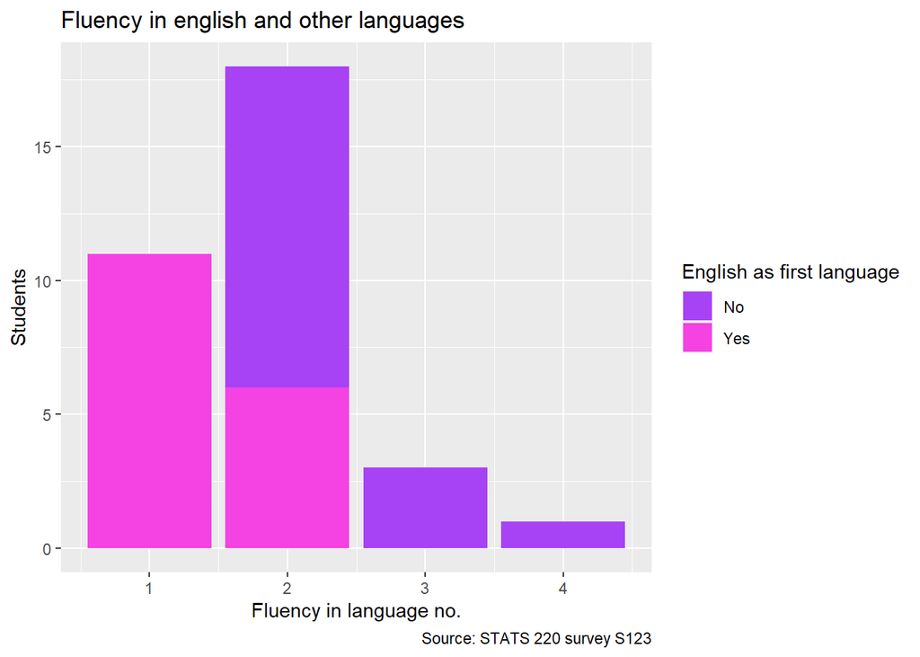

```r
# Graphing how many languages students are fluent in and whether or not English is their first language
learning_data %>%
  ggplot() +
  geom_bar(aes(x = fluent_lang,
               fill = eng_lang)) +
               scale_fill_manual(values=c("#a742f5", "#f542e3")) +
  labs(title = "Fluency in english and other languages",
       x = "Fluency in language no.",
       y = "Students",
       fill = "English as first language",
       caption = "Source: STATS 220 survey S123")
```

Figure 1: *Measuring fluency in languages number amongst students at UoA and English as first language.*

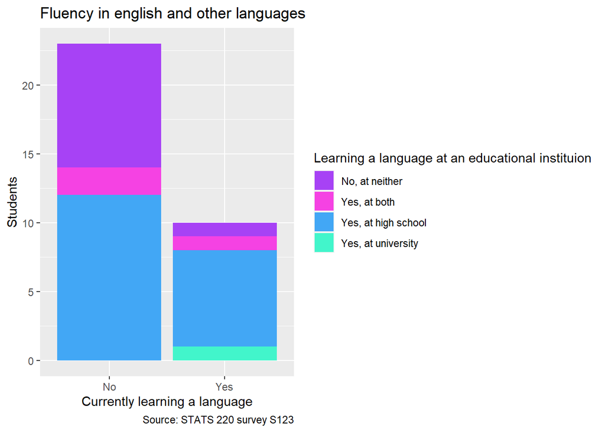

```r
# Graphing whether students are currently learning a language, and if they have learnt a language at an educational institution
learning_data %>%
  ggplot() +
  geom_bar(aes(x = learn_lang,
               fill = school_lang)) +
  scale_fill_manual(values=c("#a742f5", "#f542e3", "#42a7f5", "#42f5cb")) +
  labs(title = "Fluency in english and other languages",
       x = "Currently learning a language",
       y = "Students",
       fill = "Learning a language at an educational instituion",
       caption = "Source: STATS 220 survey S123",)
```

Figure 2: *Measuring whether UoA students are currently learning a language and if they have learnt a language at a learning institution.*

```r
# Output variables of data frame using tibble
learning_data %>%
  rename("English as first language" = 2,
         "No. of languages spoken fluently" = 3) %>%
  select(2, 3) %>%
  slice(1 : 5) %>%
  print()
```

```
##   English as first language No. of languages spoken fluently
## 1                       Yes                                2
## 2                        No                                3
## 3                       Yes                                1
## 4                       Yes                                1
## 5                       Yes                                2
```

```r
# Calculating the mean languages students are fluent in
mean_fluent_lang <- learning_data$fluent_lang %>%
  mean()

print(mean_fluent_lang)
```

```
## [1] 1.818182
```

The mean amount of languages spoken fluently by University of Auckland students is 1.8181818.

```r
# Calculating the mean languages students are fluent in
max_light_lang <- learning_data$light_lang %>%
  max()

print(max_light_lang)
```

```
## [1] 7
```

The max amount of languages spoken lightly by University of Auckland students is 7.

## Learning reflection

An important concept I had learnt in Module 2 is the importance of validating responses using regular expressions (regex). This is really important as you have to try have users input values that are relevant and realistic to the question asked. For example,I utilized this when asking my short answer numeric questions such as, “How many languages can you speak fluently?” I used certain regex because it would be unrealistic to have negative values or numbers that aren’t whole imputed. I also found the idea around considering my responses to avoid discrimination really important. A way I tried to implement inclusiveness in my survey was by including examples, so that students responding would be less likely to interpret the questions. For example, when asking “How many languages can you hold a light conversation in?”, I offered examples of what holding a light conversation could entail. Using more colloquial language such as *light conversation* may not be a familiar term with those who are not very familiar with such terms. I wanted to make sure respondents knew what they were being asked and felt confident whilst completing my survey.

I believe this project demonstrates creativity because I tried to add colour and new code in different areas. For the Google Form I wanted it to be as aesthetically pleasing as possible. As a visual learner, I like to be able to engage with a survey that has visual interest, that’s why I included photos and a colour theme. Visual interest, helps respondents gravitate to the screen, compared to using a template. I also decided to add extra code when making my graphs. I wanted them to be filled with different colours than the ones that come up automatically. I also found extra code to change the name of my key legend. This was just to improve with user understanding of what the different colours represent.

An aspect about Data Technologies that I want to further explore is anonymous vs de-identified. I think user safety is really important and I would like to further investigate ways to make sure that personal data from respondents is not being gathered. I also would like to learn more about how to ensure data safety when identifiable data is collected. I would also like to further explore tidy data and how to make sure that data has been *cleaned*. This is because I want to know more about when it is appropriate to discard data or when to investigate why there are anomalies in the data set.

```css
body {background-color: #f8f2ff;
padding: 30px;
}

p {font-size: 20px;
}


h1 {font-weight: bold;
font-family: 'Sarif';
}

h2 {text-decoration: underline;
font-weight: bold;
}
```